# Art Investing: First Insights from a data set with >228k art pieces

Jens Laufer

10 3 2021

A few weeks ago I started my “Artventure” of investing in physical art pieces. As a software/machinelearning engineer and data analyst I want to follow a data driven approach, although I am sure that my journey won’t be just dead-dry analysis as art is pure emotion. To get the answers for my questions I needed data, which I found on the website [Expresso Beans](https://expressobeans.com). The website is an art collector’s community resource built and maintained by a volunteer staff. Although the design of the website is old-fashioned, it’s a gold mine for art pieces. Thanks to the community for this excellent website.

To gain insights from the data with a analyst’s toolset I developed a web scraper in Python which pumped the data into a MongoDB database. From the database I was able to a first exploratory data analysis (EDA) with the help of R, which I like more for data analysis than Python.

In these article I want to share my results of the first analysis. In case you are interested in the data set you can send me message.

### Overall overview

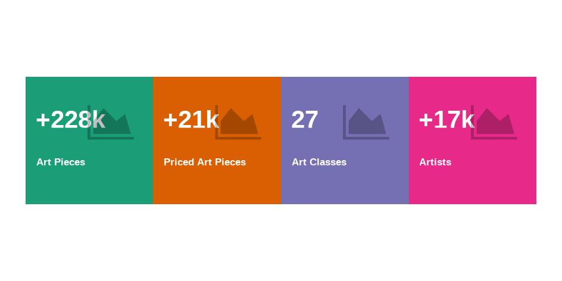